# acea_water_petrigano

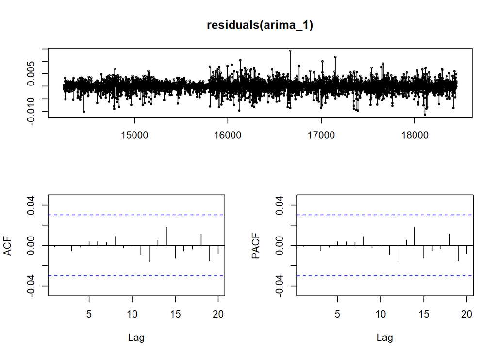

```r
tsdisplay(residuals(arima_1), lag.max = 20)
```

```r
arima <- Arima(depth_ts, order=c(14,1,16))
arima
```

```
## Series: depth_ts
## ARIMA(14,1,16)
##
## Coefficients:
```

```
##           ar1      ar2      ar3      ar4    ar5     ar6     ar7     ar8     ar9
##       -0.5177  -0.3665  -0.2249  -0.0389  0.079  0.2724  0.3915  0.2293  0.0784
## s.e.      NaN      NaN   0.1013      NaN    NaN     NaN     NaN     NaN     NaN
##          ar10     ar11     ar12     ar13    ar14      ma1      ma2      ma3
##       -0.0626  -0.2487  -0.3668  -0.5604  0.3198  -0.6029  -0.2093  -0.1114
## s.e.      NaN      NaN   0.0611      NaN     NaN      NaN      NaN      NaN
##           ma4      ma5      ma6      ma7    ma8     ma9    ma10    ma11  ma12
##       -0.1476  -0.0731  -0.1348  -0.0649  0.228  0.1337  0.1169  0.1494  0.08
## s.e.      NaN      NaN      NaN      NaN    NaN     NaN     NaN     NaN   NaN
##         ma13     ma14    ma15    ma16
##       0.1411  -0.9166  0.3819  0.0758
## s.e.     NaN      NaN     NaN  0.0213
##
## sigma^2 estimated as 4.407e-06:  log likelihood=19931.1
## AIC=-39800.2   AICc=-39799.73   BIC=-39603.6
```

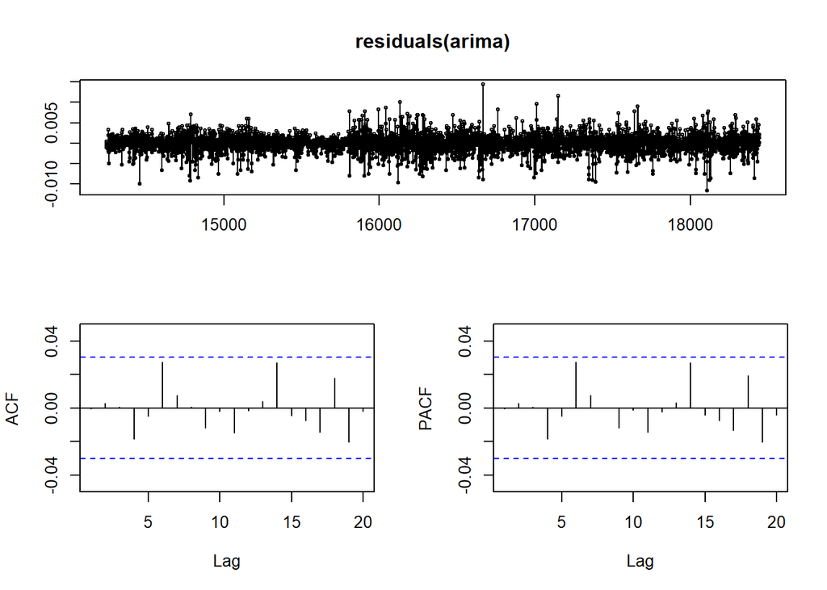

```r
tsdisplay(residuals(arima), lag.max = 20)
```

```r
arima_3 <- Arima(depth_ts, order=c(15,1,16))
arima_3
```

```
## Series: depth_ts
## ARIMA(15,1,16)
##
## Coefficients:
```

```
##           ar1      ar2      ar3      ar4    ar5     ar6    ar7      ar8
##       -0.4953  -0.2663  -0.3064  -0.2067  0.011  0.2022  0.242  -0.0109
## s.e.   0.1356      NaN   0.1258   0.0799    NaN     NaN    NaN      NaN
##           ar9     ar10     ar11     ar12     ar13    ar14    ar15      ma1
##       -0.1216  -0.0806  -0.1804  -0.3984  -0.5898  0.3692  0.1181  -0.6243
## s.e.      NaN      NaN   0.0986   0.0725   0.1158  0.0490  0.0476   0.1364
##           ma2     ma3      ma4      ma5      ma6     ma7     ma8     ma9
##       -0.2832  0.0765  -0.0727  -0.1984  -0.1254  0.0093  0.3068  0.0822
## s.e.   0.0842     NaN      NaN   0.1074   0.0549  0.0735  0.1108  0.0970
##          ma10    ma11    ma12    ma13     ma14    ma15    ma16
##       -0.0683  0.0775  0.2070  0.1328  -0.9822  0.3230  0.2033
## s.e.      NaN     NaN  0.1047  0.0579   0.0806  0.2227  0.1011
##
## sigma^2 estimated as 4.397e-06:  log likelihood=19935.57
## AIC=-39807.14   AICc=-39806.63   BIC=-39604.19
```

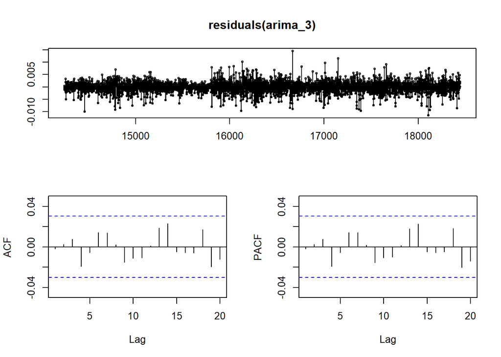

```r
tsdisplay(residuals(arima_3), lag.max = 20)
```

## Predict data

Lets predict data

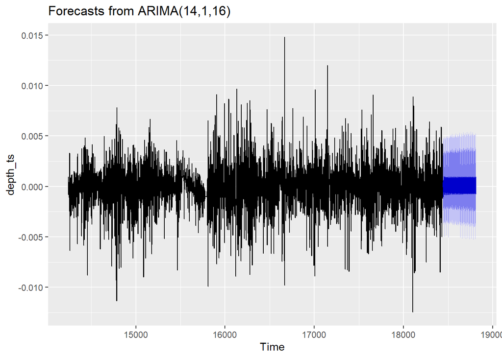

```r
autoplot(forecast(arima, h=370))
```

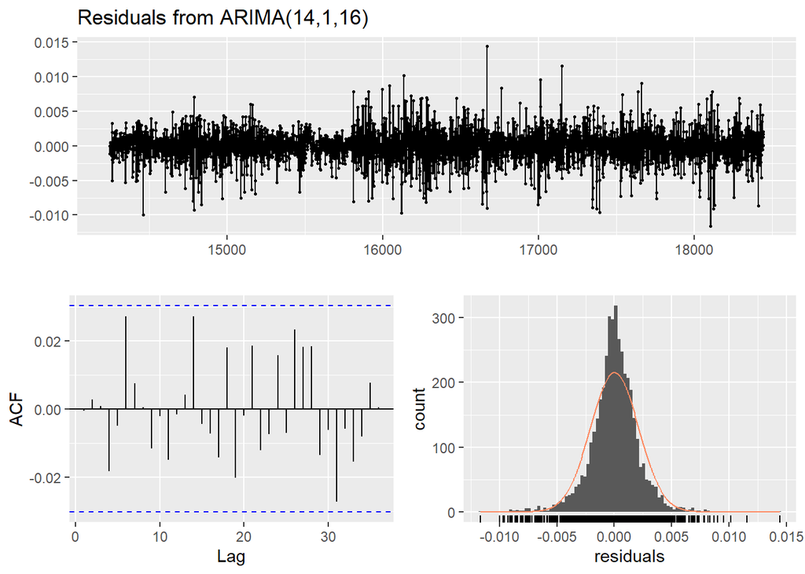

```
##
##  Ljung-Box test
##
## data:  Residuals from ARIMA(14,1,16)
## Q* = 27.828, df = 3, p-value = 3.947e-06
##
## Model df: 30.   Total lags used: 33
```

```r
checkresiduals(arima)
```

```r
auto.arima(depth_ts, seasonal=FALSE)
```

```
## Series: depth_ts
## ARIMA(2,0,2) with zero mean
##
## Coefficients:
##          ar1      ar2      ma1     ma2
##       1.1660  -0.6075  -1.2692  0.6200
## s.e.  0.0667   0.0627   0.0678  0.0611
##
## sigma^2 estimated as 4.791e-06:  log likelihood=19755.61
## AIC=-39501.21   AICc=-39501.2   BIC=-39469.5
```

## Testing model

```r
hold <- window(depth_ts, start = 4000)
```

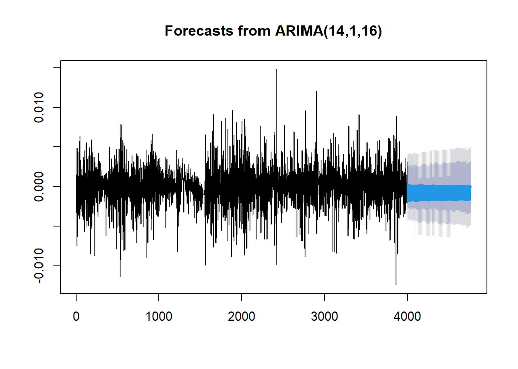

```r
fit_no_holdout <- arima(depth_ts[-c(4000:4198)], order=c(14,1, 16))
fcast_no_holdout <- forecast(fit_no_holdout,h=770)
plot(fcast_no_holdout)
lines(depth_ts[c(4000:4198)])
```

## Cross validation

We should use cross validation to choose parameters for our model.RMSE, MAE, MAPE will control quantity of our model (one of this funcs is enough) One of the most effective methods is sliding window method. It means that on the part of time series from t make predictions to t+n steps forward and count error. Then train our data and predict from t+n to t+2n till the end of the dataset. As a result we will get amount of n that can be put between training data and whole time series data. Or we can use Simulated Historical Forecasts, SHF from Prophet that has similar effect.

```r
#Fit an AR(14) model to each rolling origin subset
far14 <- function(x, h){forecast(Arima(x, order=c(14,1,16)), h=h)}
e <- tsCV(lynx, far14, h=1)

#Fit the same model with a rolling window of length 30
e <- tsCV(lynx, far14, h=1, window=30)

#Example with exogenous predictors
far14_xreg <- function(x, h, xreg, newxreg) {
  forecast(Arima(x, order=c(14,1,16), xreg=xreg), xreg=newxreg)
}

y <- ts(rnorm(50))
xreg <- matrix(rnorm(100),ncol=2)
e <- tsCV(y, far14_xreg, h=3, xreg=xreg)
```

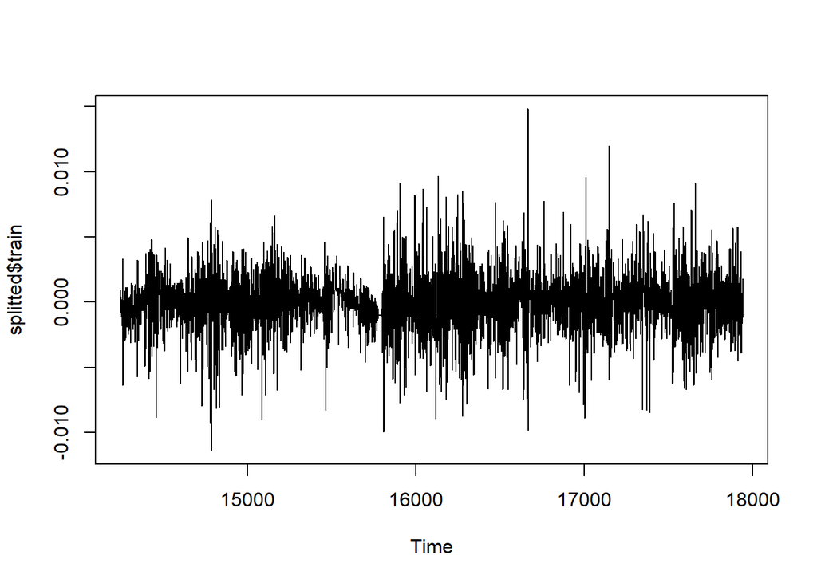

```r
splitted <- ts_split(ts.obj = depth_ts, 500)
plot(splitted$train)
```

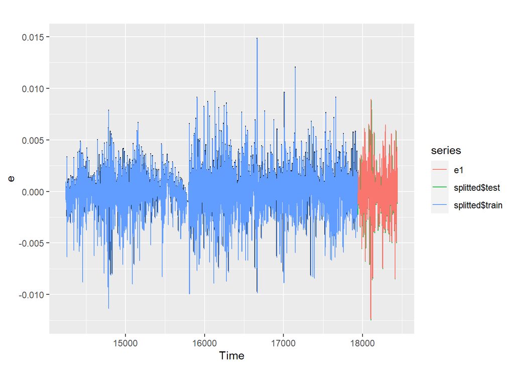

```r
far2 <- function(x, h){forecast(arima, h=h)}
e <- tsCV(splitted$train, far2, h=1)
e1 <- tsCV(splitted$test, far2, h=1)
autoplot(e) + autolayer(splitted$test) + autolayer(splitted$train) + autolayer(e1)
```